# HW4

## Question 2 - Diagnostics and Transformations

```r
data <- read.csv("datasets/auto-mpg.csv")
```

### a) Would a linear regression model be a good fit? Make a residual plot of ei vs the fitted values

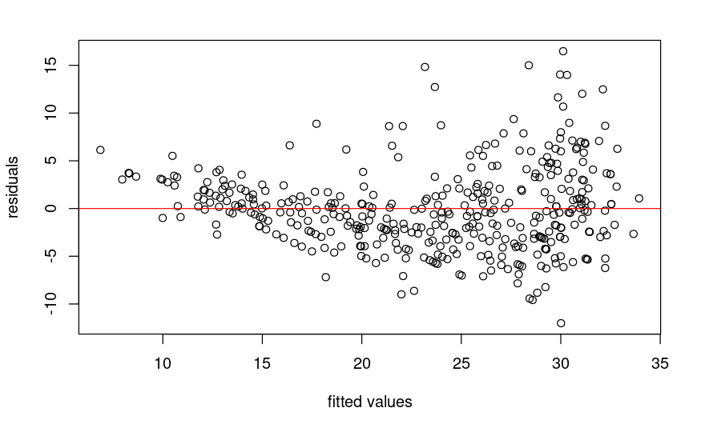

```r
model <- lm(mpg~weight, data = data)
plot(fitted(model), residuals(model), xlab = "fitted values", ylab = "residuals")
abline(h=0, col='red', pch=2)
```

```r
loess_fit <- loess(mpg~weight, data = data)
# lines(fitted(model), predict(loess_fit), col='blue')
loess_fit
```

```
Call:
loess(formula = mpg ~ weight, data = data)

Number of Observations: 398
Equivalent Number of Parameters: 4.57
Residual Standard Error: 4.197
```

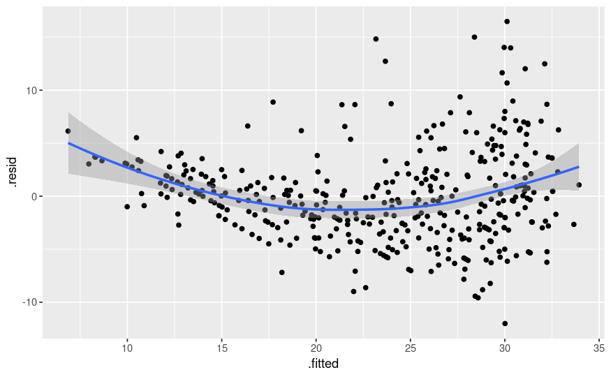

```r
ggplot(model, aes(x = .fitted, y = .resid)) + geom_point() + geom_smooth()
```

The plot seems to indicate that the linear assumption is violated (the residuals are not symmetric around zero)

### b) Apply the log transformation on weight and produce the new residual plot. What does the plot suggest about the linearity? What assumptions are violated?

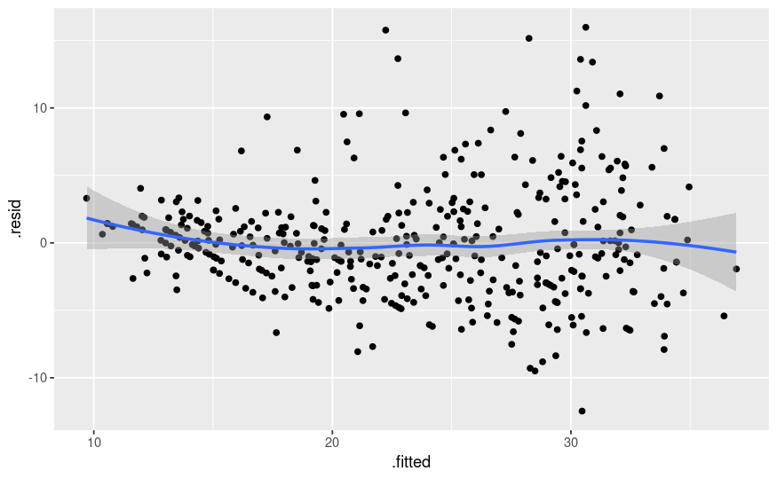

```r
log_model <- lm(mpg~log(weight), data = data)
ggplot(log_model, aes(x=.fitted, y=.resid)) + geom_point() + geom_smooth()
```

The residuals seems to be a bit more symmetric around zero, which suggests that the linearity assumption may not be violated after all. However, the homodescedaticity assumption is violated: the variance is not constant.

### c) Create a qqplot of the residuals in b) Do the residuals appear to be normally distributed

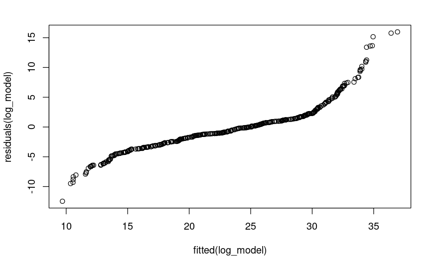

```r
qqplot(fitted(log_model), residuals(log_model))
```

The residuals don’t appear to be normally distributed since the qqplot does not resemble of a straight line, particularly around the end of the regression line, where the tail seems to fat, which suggest that the residuals are heavy tailed.

## Question 3 - Answer with respect to the final model you chose in the previous question

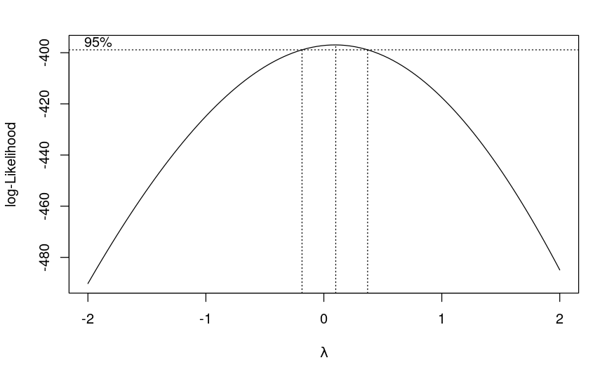

Since $\lambda$ is around 0, we know that we can transform our data with the log function and the linear regression assumptions will be met

### a) Interpret the estimated intercept and slope.

```r
coefficients(model3)
```

```
(Intercept) log(weight)
  11.521907   -1.058268
```

### b) Is there a linear association between mpg and weight after the chosen transformation using alpha=0.05. State the alternative hypothesis, decision rule and conclusion. What is the p-value of the test?

We will try to make the model a bit more linear by applying the log on both x and y variables.

H0: beta1 = 0 (there is no association between log(weight) and log(mpg)); H1: beta1 != 0 (there is an association …)

Since we have a bilateral test, we compute the p-value this way: P(|t|>t_{n-2}(0.025)), where t= (beta1 - mu)/std(beta1)

```r
# 2. compute pvalue
2*pt(t, df=n-2, lower.tail = FALSE)
```

```
[1] 1.752225e-126
```

Since pvalue = 1.75e-126 < alpha=0.05, we reject H0 and we say that there is a negative correlation between mpg and weight

### c) Find a 90% confidence interval for beta1. How do you interpret it?

We construct the confidence interval this way: beta1 +- t_{n-2}(0.05) std(beta1)

```r
# alternative
confint(model3, level = 0.9, parm = "log(weight)")
```

```
                  5 %      95 %
log(weight) -1.106905 -1.009631
```

The 90% confidence interval for beta1 is [-1.1069, -1.0096]. We can interpret it as follows: if we reject beta1 whenever it is outside the confidence interval, we would be right about 90% of the time.

## Question 4 - Data Analysis Practice

We first load the data

1. Introduce the research problem and describe the research hypothesis.

We would like to predict abalones age using their height measurements using a simple linear regression with normal error assumption. The number of rings correspond to the abalone’s age.

Our hypothesis: - H0: There is no association between abalones height and age (beta1 = 0) - H1: The is a positive association between abalones height and age (beta1> 0)

Our hypothesis is unilateral

FORMAL INTRODUCTION:

The term `abalone` is a common name for a broad class of marine snails, ranging from a few millimeter to a few inches. The age of an abalone can be determined by counting the number of rings on its outer shell. However, since this process requires the use of a microscope, we would like to use its height to predict its age because this measurement is easier to obtain. In this analysis, we will build a predictive model to predict abalone age from its height.

2. Examine the two variables individually (univariate). Find summary measures of each (mean, variance, range, etc). Graphically display each. Describe your graph. What is the unit of height

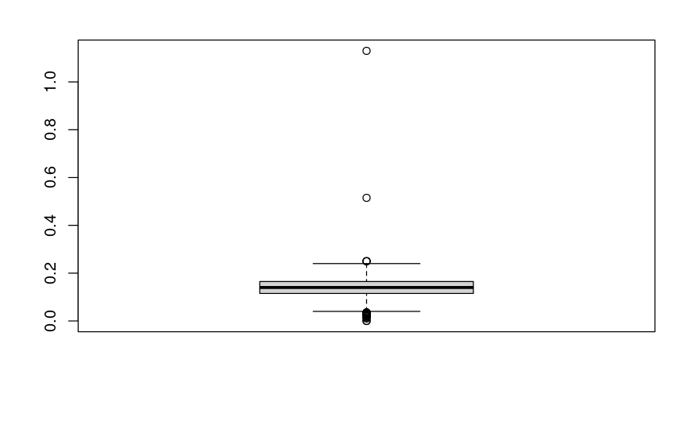

Summary for the rings variables:

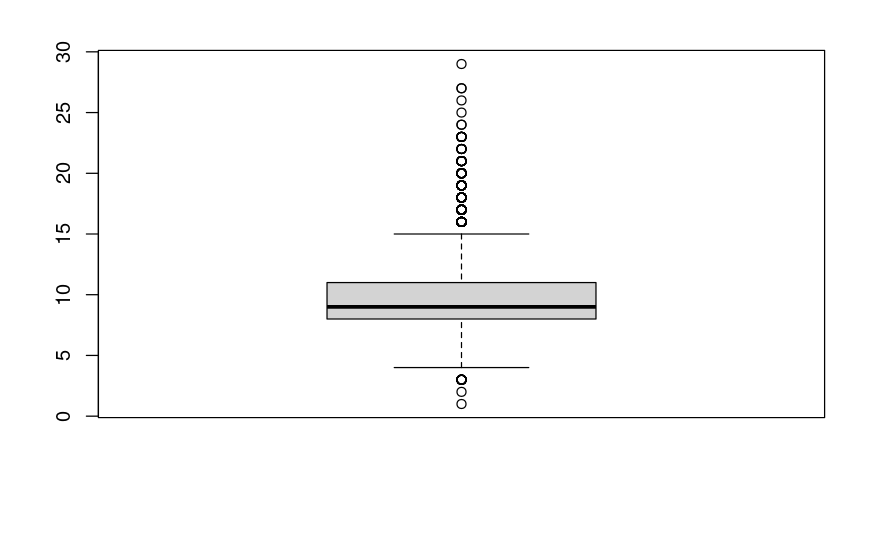

c-d) Generate a labeled scatterplot of the data. Describe interesting features/trends Fit a simple linear regression to the data predicting number of rings using the height of the abalones. Plot it in the scatterplot and describe the line’s fit

```r
ggplot(data, aes(Height, Rings)) + geom_point(alpha=0.2) + geom_smooth(method = 'lm')
```

[output not shown]

5. Verify if the model assumptions are met. If not, transform height/rings and refit the model. Justify your decisions and recheck your diagnosis

To verify the model assumptions (homodescaticity: constant variance on errors and mean residuals is 0), we will: - draw qqplot - residual plot

```r
qqplot(data$Height, data$Rings)
model4 <- lm(Rings~Height, data = data)
plot(data$Height, residuals(model4))
abline(h=0, col='blue')
```

[output not shown]

It seems that the model violates the linear regression assumptions. We will use a Box Cox plot to find the transformation needed so that the assumptions are met

```r
boxcox(lm(Rings~Height, data = data))
```

[output not shown]

There seems to be a non-linear trend and that the homoscedacity assumption isn’t met. However, because we want to make inference later, we will NOT perform any transformation on the data.

6. Interpret your final parameter estimates in context. Provides 95% confidence interval for beta0 and beta1. Interpret in context of the problem

[figure not shown]

```r
# linear regression parameters estimate
model4 <- lm(Rings~Height, data = data_no_outliers)
summary(model)
```

[output not shown]